# Pattern recognition course project part 2

In this notebook I will classify american sign language alphabet using Pytorch and deep learning networks, A pre-trained model from PyTorch models zoo will be used and we will retrain the last parts of the network on our problem.

PyTorch will be used to build and train a deep learning model to classify images to 29 classes (26 ASL alphabet, space, Del, and nothing).

## 1. Fetching data

### Get Kaggle CLI and torch vision package

```python
#install torchvision and kaggle
!pip install torchvision
!pip install kaggle
```

### Download and unzip the dataset

the dataset of 87.0k ASL Alphabet images (JPG) and 29 categories (26 ASL alphabet, space, Del, and nothing) offered by amarinderplasma on Kaggle will be used. the dataset [ASL Images.](https://www.kaggle.com/amarinderplasma/alphabets-sign-language)

```python
# download dataset and extract it
! export KAGGLE_USERNAME="mostafaabdelhameed" && export KAGGLE_KEY="5b15504cc4f5e70b2b3227d3bfc71895" && kaggle datasets download --unzip amarinderplasma/alphabets-sign-language
! ls
```

```
Downloading alphabets-sign-language.zip to /home/wsuser/work
asl_alphabet_1	asl_alphabet_test  asl_alphabet_train  asl_alphabet_valid
```

# 2. Explore Data

```python
! pwd && ls
print("\nFolders(classess) in training folder: ...")
! cd asl_alphabet_train && ls
```

```
/home/wsuser/work
asl_alphabet_1	asl_alphabet_test  asl_alphabet_train  asl_alphabet_valid

Folders(classess) in training folder: ...
A  C  del  F  H  J  L  N	O  Q  S      T	V  X  Z
B  D  E    G  I  K  M  nothing	P  R  space  U	W  Y
```

### importing needed libs

```python
#import  needed libraries and check the used gpu
import torch
from torch import nn,optim
from torchvision import transforms, models ,datasets
import numpy as np
import matplotlib.pyplot as plt
import glob
from mpl_toolkits.axes_grid1 import ImageGrid
```

### show sample of data

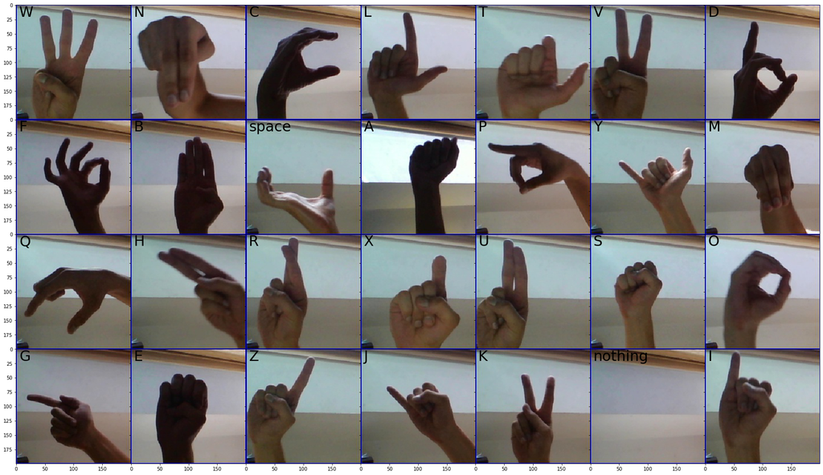

```python
%matplotlib inline

ASL=np.array(glob.glob('asl_alphabet_test/*'))

fig = plt.figure(figsize=(30, 30))
grid = ImageGrid(fig, 111,
                 nrows_ncols=(4, 7),
                 axes_pad=0,  # pad between axes in inch.
                 )
l=0
for img in ASL:
        im=plt.imread(img)
        grid[l].imshow(im,cmap='gray',interpolation='nearest')
        grid[l].text(5,20, img.split('/')[1].split('_')[0] ,fontsize=30)
        l+=1
```

# 3. Process and load images

## define transformers

```python
#creating the dataloaders

# Define transforms for the training data and testing data
train_path='asl_alphabet_train'
valid_path='asl_alphabet_valid'

train_transforms = transforms.Compose([transforms.Resize((224,224)),
                                       transforms.RandomRotation(30),
                                       transforms.RandomHorizontalFlip(p=0.3),
                                       transforms.ToTensor(),
                                       transforms.Normalize([0.485, 0.456, 0.406],
                                                            [0.229, 0.224, 0.225])])

test_transforms = transforms.Compose([transforms.Resize((224,224)),
                                      transforms.ToTensor(),
                                      transforms.Normalize([0.485, 0.456, 0.406],
                                                            [0.229, 0.224, 0.225])])
```

## load images to data loaders

```python
# load data to loaders
train_data = datasets.ImageFolder(train_path, transform=train_transforms)
test_data = datasets.ImageFolder(valid_path, transform=test_transforms)

trainloader = torch.utils.data.DataLoader(train_data, batch_size=512, shuffle=True)
testloader = torch.utils.data.DataLoader(test_data, batch_size=512)

#print used Device
print(f"Device used: {torch.cuda.get_device_name(0)}")

#print class to index mapping
print(f"class to index mapping: {train_data.class_to_idx}")
```

```
Device used: Tesla K80
class to index mapping: {'A': 0, 'B': 1, 'C': 2, 'D': 3, 'E': 4, 'F': 5, 'G': 6, 'H': 7, 'I': 8, 'J': 9, 'K': 10, 'L': 11, 'M': 12, 'N': 13, 'O': 14, 'P': 15, 'Q': 16, 'R': 17, 'S': 18, 'T': 19, 'U': 20, 'V': 21, 'W': 22, 'X': 23, 'Y': 24, 'Z': 25, 'del': 26, 'nothing': 27, 'space': 28}
```

# 4. Customize our network

## Choose a Pretrained model

choose a pre-trained model and freeze all layers to make sure not all the network is trained during the training process.  
print the model classifier to check the number of input neurons to consider when creating the classifier.

```python
# choose a pretrained model
model = models.mobilenet_v2(pretrained=True)

# Freeze parameters of the tarined network
for param in model.parameters():
    param.requires_grad = False

#print the model to check the classifer and change it
print (model.classifier)
```

```
Sequential(
  (0): Dropout(p=0.2, inplace=False)
  (1): Linear(in_features=1280, out_features=1000, bias=True)
)
```

## Choose which layers to train

unfreeze some of the last blocks of the NN and define custom classifier to have 29 outputs then attach it to the model.  
Also choose the optimizer and define the learning rate for it.

```python
# define new classifier and append it to network but remember to have a 29-neuron output layer for our two classes.
model.classifier= nn.Sequential(nn.Dropout(p=0.6, inplace=False),
                                nn.Linear(in_features=1280, out_features=29, bias=True),
                                nn.LogSoftmax(dim=1))

# unlock last three blocks before the classifier(last layer).
for p in model.features[-3:].parameters():
    p.requires_grad = True


# choose your loss function
criterion = nn.NLLLoss()

# define optimizer to train only the classifier and the previous three block.
optimizer = optim.Adam([{'params':model.features[-1].parameters()},
                        {'params':model.features[-2].parameters()},
                        {'params':model.features[-3].parameters()},
                        {'params':model.classifier.parameters()}], lr=0.0005)

# define Learning Rate scheduler to decrease the learning rate by multiplying it by 0.1 after each epoch on the data.
scheduler = torch.optim.lr_scheduler.StepLR(optimizer, step_size=1, gamma=0.1)

#print the classifier now
print(model.classifier)

#print the whole model
# print(model)
```

```
Sequential(
  (0): Dropout(p=0.6, inplace=False)
  (1): Linear(in_features=1280, out_features=29, bias=True)
  (2): LogSoftmax(dim=1)
)
```

# 5. Try the model before any training

```
image number 149
---------------------
label: H
prediction: V
```

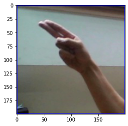

```python
### try your model on some images
%matplotlib inline

device = torch.device("cuda:0" if torch.cuda.is_available() else "cpu")
model.to(device)

#turn model to evaluation mode
model.eval()

#load some of the test data
test_data_t = datasets.ImageFolder(valid_path,transforms.Compose([transforms.ToTensor()]))
testloader_t = torch.utils.data.DataLoader(test_data_t, batch_size=200,shuffle=True)
images_t , labels_t=next( iter(testloader_t) )

#Choose arandom image from 0 to 199
index = np.random.randint(0, 199)
test_img=images_t[index]

#show choosed image
t=transforms.ToPILImage()
plt.imshow(t(test_img))

#normalize image as in the training data
t_n=transforms.Normalize([0.485, 0.456, 0.406],[0.229, 0.224, 0.225])
test_img=t_n(test_img).unsqueeze(0).cuda()

#classify image using our model
res = torch.exp(model(test_img))

#invert class_to_idx keys to values and viceversa.
classes=train_data.class_to_idx
classes = {value:key for key, value in classes.items()}

print(f"image number {index}")
print("---------------------")

#print real class
print("label:",classes[labels_t[index].item()])

#print predicted class
print("prediction:", classes[res.argmax().item()])
```

# 6. Configure training parameters and start the training

## choose the number of epochs and printing intervals and move the model to the GPU

```python
#Define number of epochs through data and run the training loop
import math
device = torch.device("cuda:0" if torch.cuda.is_available() else "cpu")
model.to(device)
epochs = 2
step = 0
running_loss = 0
print_every = 5
trainlossarr=[]
testlossarr=[]
oldacc=0

steps=math.ceil(len(train_data)/(trainloader.batch_size))
```

## Start the training loop

```python
%%time

for epoch in range(epochs):
    print(f"--------------------------------- START OF EPOCH [ {epoch+1} ] >>> LR =  {optimizer.param_groups[-1]['lr']} ---------------------------------\n")
    for inputs, labels in trainloader:
        model.train()
        step += 1
        inputs=inputs.to(device)
        labels=labels.to(device)

        optimizer.zero_grad()

        props = model.forward(inputs)
        loss = criterion(props, labels)
        loss.backward()
        optimizer.step()

        running_loss += loss.item()

        if (step % print_every == 0) or (step==steps):
            test_loss = 0
            accuracy = 0
            model.eval()
            with torch.no_grad():
                for inputs, labels in testloader:
                    inputs, labels = inputs.to(device), labels.to(device)
                    props = model.forward(inputs)
                    batch_loss = criterion(props, labels)

                    test_loss += batch_loss.item()

                    # Calculate accuracy
                    ps = torch.exp(props)
                    top_p, top_class = ps.topk(1, dim=1)
                    equals = top_class == labels.view(*top_class.shape)
                    accuracy += torch.mean(equals.type(torch.FloatTensor)).item()




            print(f"Epoch ({epoch+1} of {epochs}) ... "
                  f"Step  ({step:3d} of {steps}) ... "
                  f"Train loss: {running_loss/print_every:.3f} ... "
                  f"Test loss: {test_loss/len(testloader):.3f} ... "
                  f"Test accuracy: {accuracy/len(testloader):.3f} ")
            trainlossarr.append(running_loss/print_every)
            testlossarr.append(test_loss/len(testloader))
            running_loss = 0


    scheduler.step()
    step=0
```

```
--------------------------------- START OF EPOCH [ 1 ] >>> LR =  0.0005 ---------------------------------

Epoch (1 of 2) ... Step  (  5 of 142) ... Train loss: 3.212 ... Test loss: 2.667 ... Test accuracy: 0.432
Epoch (1 of 2) ... Step  ( 10 of 142) ... Train loss: 2.400 ... Test loss: 1.729 ... Test accuracy: 0.597
Epoch (1 of 2) ... Step  ( 15 of 142) ... Train loss: 1.762 ... Test loss: 1.198 ... Test accuracy: 0.713
Epoch (1 of 2) ... Step  ( 20 of 142) ... Train loss: 1.277 ... Test loss: 0.901 ... Test accuracy: 0.818
Epoch (1 of 2) ... Step  ( 25 of 142) ... Train loss: 0.955 ... Test loss: 0.720 ... Test accuracy: 0.861
Epoch (1 of 2) ... Step  ( 30 of 142) ... Train loss: 0.746 ... Test loss: 0.608 ... Test accuracy: 0.886
Epoch (1 of 2) ... Step  ( 35 of 142) ... Train loss: 0.569 ... Test loss: 0.508 ... Test accuracy: 0.913
Epoch (1 of 2) ... Step  ( 40 of 142) ... Train loss: 0.493 ... Test loss: 0.432 ... Test accuracy: 0.914
Epoch (1 of 2) ... Step  ( 45 of 142) ... Train loss: 0.436 ... Test loss: 0.356 ... Test accuracy: 0.939
Epoch (1 of 2) ... Step  ( 50 of 142) ... Train loss: 0.360 ... Test loss: 0.336 ... Test accuracy: 0.936
Epoch (1 of 2) ... Step  ( 55 of 142) ... Train loss: 0.302 ... Test loss: 0.301 ... Test accuracy: 0.944
Epoch (1 of 2) ... Step  ( 60 of 142) ... Train loss: 0.276 ... Test loss: 0.278 ... Test accuracy: 0.941
Epoch (1 of 2) ... Step  ( 65 of 142) ... Train loss: 0.245 ... Test loss: 0.267 ... Test accuracy: 0.943
Epoch (1 of 2) ... Step  ( 70 of 142) ... Train loss: 0.236 ... Test loss: 0.248 ... Test accuracy: 0.946
Epoch (1 of 2) ... Step  ( 75 of 142) ... Train loss: 0.205 ... Test loss: 0.215 ... Test accuracy: 0.951
Epoch (1 of 2) ... Step  ( 80 of 142) ... Train loss: 0.186 ... Test loss: 0.234 ... Test accuracy: 0.939
Epoch (1 of 2) ... Step  ( 85 of 142) ... Train loss: 0.169 ... Test loss: 0.203 ... Test accuracy: 0.948
Epoch (1 of 2) ... Step  ( 90 of 142) ... Train loss: 0.159 ... Test loss: 0.184 ... Test accuracy: 0.956
Epoch (1 of 2) ... Step  ( 95 of 142) ... Train loss: 0.140 ... Test loss: 0.170 ... Test accuracy: 0.960
Epoch (1 of 2) ... Step  (100 of 142) ... Train loss: 0.148 ... Test loss: 0.176 ... Test accuracy: 0.953
Epoch (1 of 2) ... Step  (105 of 142) ... Train loss: 0.129 ... Test loss: 0.189 ... Test accuracy: 0.948
Epoch (1 of 2) ... Step  (110 of 142) ... Train loss: 0.115 ... Test loss: 0.171 ... Test accuracy: 0.958
Epoch (1 of 2) ... Step  (115 of 142) ... Train loss: 0.115 ... Test loss: 0.156 ... Test accuracy: 0.959
Epoch (1 of 2) ... Step  (120 of 142) ... Train loss: 0.111 ... Test loss: 0.140 ... Test accuracy: 0.967
Epoch (1 of 2) ... Step  (125 of 142) ... Train loss: 0.101 ... Test loss: 0.133 ... Test accuracy: 0.967
Epoch (1 of 2) ... Step  (130 of 142) ... Train loss: 0.092 ... Test loss: 0.145 ... Test accuracy: 0.957
Epoch (1 of 2) ... Step  (135 of 142) ... Train loss: 0.090 ... Test loss: 0.118 ... Test accuracy: 0.969
Epoch (1 of 2) ... Step  (140 of 142) ... Train loss: 0.095 ... Test loss: 0.129 ... Test accuracy: 0.965
Epoch (1 of 2) ... Step  (142 of 142) ... Train loss: 0.034 ... Test loss: 0.122 ... Test accuracy: 0.966
--------------------------------- START OF EPOCH [ 2 ] >>> LR =  5e-05 ---------------------------------

Epoch (2 of 2) ... Step  (  5 of 142) ... Train loss: 0.090 ... Test loss: 0.121 ... Test accuracy: 0.966
Epoch (2 of 2) ... Step  ( 10 of 142) ... Train loss: 0.080 ... Test loss: 0.121 ... Test accuracy: 0.966
Epoch (2 of 2) ... Step  ( 15 of 142) ... Train loss: 0.068 ... Test loss: 0.120 ... Test accuracy: 0.966
Epoch (2 of 2) ... Step  ( 20 of 142) ... Train loss: 0.061 ... Test loss: 0.120 ... Test accuracy: 0.967
Epoch (2 of 2) ... Step  ( 25 of 142) ... Train loss: 0.065 ... Test loss: 0.116 ... Test accuracy: 0.967
Epoch (2 of 2) ... Step  ( 30 of 142) ... Train loss: 0.061 ... Test loss: 0.114 ... Test accuracy: 0.968
Epoch (2 of 2) ... Step  ( 35 of 142) ... Train loss: 0.068 ... Test loss: 0.113 ... Test accuracy: 0.968
```

[output cut: 9 more lines]

```
Epoch (2 of 2) ... Step  ( 85 of 142) ... Train loss: 0.060 ... Test loss: 0.106 ... Test accuracy: 0.971
Epoch (2 of 2) ... Step  ( 90 of 142) ... Train loss: 0.064 ... Test loss: 0.105 ... Test accuracy: 0.971
Epoch (2 of 2) ... Step  ( 95 of 142) ... Train loss: 0.057 ... Test loss: 0.103 ... Test accuracy: 0.972
Epoch (2 of 2) ... Step  (100 of 142) ... Train loss: 0.067 ... Test loss: 0.103 ... Test accuracy: 0.971
Epoch (2 of 2) ... Step  (105 of 142) ... Train loss: 0.069 ... Test loss: 0.103 ... Test accuracy: 0.971
Epoch (2 of 2) ... Step  (110 of 142) ... Train loss: 0.068 ... Test loss: 0.103 ... Test accuracy: 0.972
Epoch (2 of 2) ... Step  (115 of 142) ... Train loss: 0.062 ... Test loss: 0.104 ... Test accuracy: 0.971
Epoch (2 of 2) ... Step  (120 of 142) ... Train loss: 0.067 ... Test loss: 0.105 ... Test accuracy: 0.971
Epoch (2 of 2) ... Step  (125 of 142) ... Train loss: 0.058 ... Test loss: 0.106 ... Test accuracy: 0.970
Epoch (2 of 2) ... Step  (130 of 142) ... Train loss: 0.056 ... Test loss: 0.105 ... Test accuracy: 0.970
Epoch (2 of 2) ... Step  (135 of 142) ... Train loss: 0.051 ... Test loss: 0.104 ... Test accuracy: 0.969
Epoch (2 of 2) ... Step  (140 of 142) ... Train loss: 0.055 ... Test loss: 0.103 ... Test accuracy: 0.970
Epoch (2 of 2) ... Step  (142 of 142) ... Train loss: 0.024 ... Test loss: 0.103 ... Test accuracy: 0.970
CPU times: user 8h 43min 56s, sys: 20min 39s, total: 9h 4min 36s
Wall time: 1h 14min 10s
```

# 7. Test The Model After Training

```python
### try your model on some images
%matplotlib inline

#turn model to evaluation mode
model.eval()

#load some of the test data
test_data = datasets.ImageFolder(valid_path,transforms.Compose([transforms.ToTensor()]))
testloader = torch.utils.data.DataLoader(test_data, batch_size=200,shuffle=True)
images , labels=next( iter(testloader) )
```

```
image number 145
---------------------
label: L
prediction: L
```

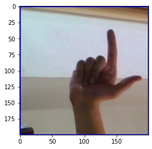

```python
#Choose arandom image from 0 to 199
index = np.random.randint(0, 199)
test_img=images[index]

#show choosed image
t=transforms.ToPILImage()
plt.imshow(t(test_img))

#normalize image as in the training data
t_n=transforms.Normalize([0.485, 0.456, 0.406],[0.229, 0.224, 0.225])
test_img=t_n(test_img).unsqueeze(0).cuda()

#classify image using our model
res = torch.exp(model(test_img))

#invert class_to_idx keys to values and viceversa.
classes=train_data.class_to_idx
classes = {value:key for key, value in classes.items()}

print(f"image number {index}")
print("---------------------")

#print real class
print("label:",classes[labels[index].item()])

#print predicted class
print("prediction:", classes[res.argmax().item()])
```

## Analysis and comments

In this exercise, we used the idea of transfer learning where we can use a pre-trained NN and only retrain a portion of the network to achieve our target which was to classify different American sign language characters, and doing so we were able to make use of the trained network and save both computation power and time.

Another thing to note is that I initially tried to retrain the last block of the network along with the classifier fabricated for the task and then tried the same thing but this time with the last three blocks instead of one and as you can see in the picture below (training log of one layer and the classifier) the accuracy was lower than that of the one in this notebook ( training with three layers instead of one )

[figure not shown]

As you can see also in the training log above we can see that the accuracy started to fluctuate towards the end of the first epoch but at the start of the second epoch we can see the loss starting to decay again because we decreased the learning rate giving the model more flexibility and lower steps to find the optimum solution